# C:N Ratios

Meyer, R.

2022-4-4

# Summary Tables

## C:N ratios

- ar = Annual Rye
- cr = Cereal Rye
- pc = Wild Type Pennycress
- gm = Gene Edited AOP2 Pennycress

Table 1. Carbon to nitrogen ratio, percent carbon, and percent nitrogen by species.

| spp | avg_pct_n | avg_pct_c | c_n_ratio |
| --- | --- | --- | --- |
| ar | 1.741304 | 35.23478 | 20.77427 |
| cr | 1.471064 | 37.33830 | 26.15907 |
| gm | 1.500851 | 41.41702 | 27.92590 |
| pc | 1.847447 | 41.87021 | 23.27899 |

## C:N ratios by plot

Table 2. Carbon to nitrogen ratio, percent carbon, and percent nitrogen by species with plot. Plots were determined by placing samples in the two most prevalent soil types in central Illinois.

| spp | plot | avg_pct_n | avg_pct_c | c_n_ratio |
| --- | --- | --- | --- | --- |
| ar | 1 | 1.657727 | 33.89545 | 20.80510 |
| ar | 2 | 1.817917 | 36.46250 | 20.74602 |
| cr | 1 | 1.433043 | 36.73478 | 26.18316 |
| cr | 2 | 1.507500 | 37.91667 | 26.13600 |
| gm | 1 | 1.453809 | 41.26190 | 28.80456 |
| gm | 2 | 1.538846 | 41.54231 | 27.21621 |
| pc | 1 | 1.792174 | 41.24348 | 23.57482 |
| pc | 2 | 1.900417 | 42.47083 | 22.99549 |

# Summary Figure

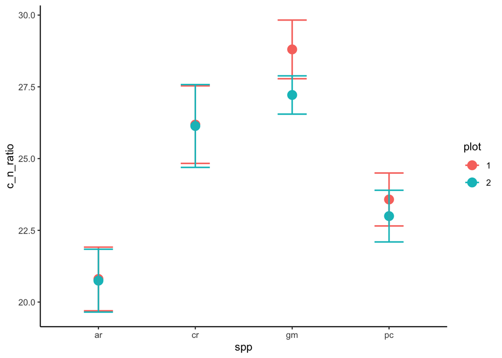

Figure 1. Mean and standard error of carbon to nitrogen ratio by species with color as plot.